# S610 Final Project

Junying Tong

2025-12-06

## Introduction to the Problem

- The purpose of this project: Evaluate the impacts of several meteorological parameters on the count of prescribed fire (Rx) occurrence. Through the *forward stepwise selection* approach:
  - first, find the “best” combination of parameters to estimate the number of Rx;
  - second, explore the post-selection inference (how does this approach affect the validity of the p-values and confidence intervals).
- Data sources:
  - Fire weather: ERA5 Reanalysis (https://www.ecmwf.int/en/forecasts/dataset/ecmwf-reanalysis-v5)
  - Fire Activity in the U.S.: The Environmental Protection Agency, Beidler, Pouliout, and Foley, 2024.
- Workflow:
  - Create a custom forward-selection function manually.
  - Apply the function to the fire–weather dataset to identify the “best” model.
  - Use simulation to test whether post-selection inference behaves as theory predicts.
- Motivate the design choice and functions:
  - The manually-written selection function provides full transparency in how variables are chosen.
  - The simulation under a null assumption isolates the effect of model selection and is useful in experimentation with known expectations of the results.
  - The selection frequency and conditional type I error are stored and visualized to verify the expected post-selection behavior of the model.
- Evidence provided that the code does what it should:
  - Post-selection p-values show inflated type I error, confirming the expected failure of standard inference.
  - In simulation, stepwise selection frequently chooses variables even when the true effect is zero.

### Problem Setup: Clean the Raw Data and Define the Regressions.

```r
## Read in the fire and weather conditions data.
df <- read.csv(file.path(path_in, "Fire_weather_daily_county_data.csv"))
df <- as.data.frame(df)

## Independent variables: daily county-level average weather parameters.
predictors <- grep("^mean_", names(df), value = TRUE)
predictors # 9 variables in total
```

```
## [1] "mean_kbdi"      "mean_twsml"     "mean_tws10m"    "mean_t2m_F"
## [5] "mean_vent_rate" "mean_ddi"       "mean_lvori"     "mean_blh"
## [9] "mean_rh"
```

```r
## Define the null and full regression equations.
model_null <- n_fires ~ 1
model_full <- as.formula(
  paste("n_fires ~", paste(grep("^mean_", names(df), value = TRUE), collapse = " + "))
)
```

### Forward Stepwise Selection Using AIC as the Selection on the Observed Data.

```r
## Starts from the null model and adds one predictor at a time,
#  keeping any addition that lowers AIC, until no further improvement.
forward_select_lm <- function(df, response, candidates) {
  data <- as.data.frame(df)
  in_model   <- character(0)
  best_model <- lm(as.formula(paste(response, "~ 1")), data = data)  # intercept-only model
  best_aic   <- AIC(best_model)

  repeat {
    remaining <- setdiff(candidates, in_model) # predictors that are not yet added
    if (length(remaining) == 0) break

    aic_vec <- numeric(length(remaining))  # add a placeholder for AIC for adding each remaining candidates.
    for (j in seq_along(remaining)) {
      vars <- c(in_model, remaining[j])
      form <- as.formula(paste(response, "~", paste(vars, collapse = " + ")))
      fit  <- lm(form, data = data)
      aic_vec[j] <- AIC(fit)
    }

    j_best   <- which.min(aic_vec) # selects the best predictor that has the lowest AIC
    new_aic  <- aic_vec[j_best]

    if (new_aic >= best_aic) break # stop if no AIC improvement

    # update the current "best model" and the predictor combo.
    in_model <- c(in_model, remaining[j_best])
    best_aic <- new_aic
    best_model <- lm(as.formula(paste(response, "~", paste(in_model, collapse = " + "))),data = data)
  }

  best_model
}

## Call the loop
fit_selected <- forward_select_lm(df, "n_fires", predictors)
summary(fit_selected)
```

```
##
## Call:
## lm(formula = as.formula(paste(response, "~", paste(in_model,
##     collapse = " + "))), data = data)
##
## Residuals:
##    Min     1Q Median     3Q    Max
## -0.345 -0.112 -0.078 -0.038 10.794
##
## Coefficients:
##                 Estimate Std. Error t value Pr(>|t|)
## (Intercept)     5.06e-01   4.40e-03  114.90   <2e-16 ***
## mean_rh        -4.20e-03   7.18e-05  -58.53   <2e-16 ***
## mean_blh       -2.17e-05   7.34e-07  -29.50   <2e-16 ***
## mean_kbdi      -6.79e-04   3.73e-05  -18.23   <2e-16 ***
## mean_ddi        2.68e-04   1.49e-05   17.98   <2e-16 ***
## mean_t2m_F     -1.03e-03   5.45e-05  -18.96   <2e-16 ***
## mean_lvori     -7.65e-03   6.33e-04  -12.09   <2e-16 ***
## mean_vent_rate -3.26e-07   3.38e-08   -9.64   <2e-16 ***
## mean_twsml      1.89e-03   2.27e-04    8.36   <2e-16 ***
## ---
## Signif. codes:  0 '***' 0.001 '**' 0.01 '*' 0.05 '.' 0.1 ' ' 1
##
## Residual standard error: 0.353 on 552749 degrees of freedom
## Multiple R-squared:  0.0283, Adjusted R-squared:  0.0283
## F-statistic: 2.01e+03 on 8 and 552749 DF,  p-value: <2e-16
```

### Simulation Set-up: Imposing a Known “True” Data Generating Process (DGP).

```r
setDT(df)
X <- as.matrix(df[, ..predictors])  # create a matrix composed of elements in predictors (weather conditions)
#beta_true <- rep(0, length(predictors)) # imposing zeros as the true coefficients for all predictors
#names(beta_true) <- predictors

## Repeat 500 times and measure the “post-selection” type I error
run_simulation <- function(R = 500, sigma_true = 1) {   # SE of error for simulated outcomes
  n <- nrow(df)
  selected <- logical(R)
  pvals <- rep(NA_real_, R)
  beta_hat <- rep(NA_real_, R)  # store estimated coefficient when selected

  for (i in seq_len(R)) {
    ## 1. simulate outcome under the "null effects" assumption
    # generate n_fires under the null
    # imposing zeros as the true coefficients for all predictors
    epsilon <- rnorm(n, mean = 0, sd = sigma_true)
    data_sim <- as.data.frame(df)
    data_sim$n_fires <- epsilon  # the dependent variable becomes pure noise.

    ## 2. run forward stepwise selection
    fwd_fit <- forward_select_lm(data_sim, "n_fires", predictors)

    ## 3. extract p-value for mean_t2m_F if selected
    summary_stats <- summary(fwd_fit)
    row_names <- rownames(summary_stats$coef)

    if ("mean_t2m_F" %in% row_names) {  # take "mean 2m-temperature Fahrenheit" as an example
      pvals[i] <- summary_stats$coef["mean_t2m_F", "Pr(>|t|)"]
      beta_hat[i] <- summary_stats$coef["mean_t2m_F", "Estimate"]
      selected[i] <- TRUE
    } else {
      selected[i] <- FALSE
      pvals[i] <- NA_real_
      beta_hat[i] <- NA_real_
    }
  }

  list(selected = selected, pvals = pvals, beta_hat = beta_hat) # store the selection status/p-value/coefficient
}

## Call the loop
set.seed(123)
sim_results <- run_simulation(R = 500, sigma_true = 1)

## How often is mean_t2m_F selected for the best model?
mean(sim_results$selected)
```

```
## [1] 0.11
```

```r
## Conditional on being selected, how often is p < 0.05? (type I error)
mean(sim_results$pvals[sim_results$selected] < 0.05, na.rm = TRUE)
```

```
## [1] 0.5636
```

```r
## This means: Among the simulations where mean_t2m_F is selected, its p-value is < 0.05 about 56% of the time, even though the true effect is 0.
```

### Plot the Density of Simulated Coefficients.

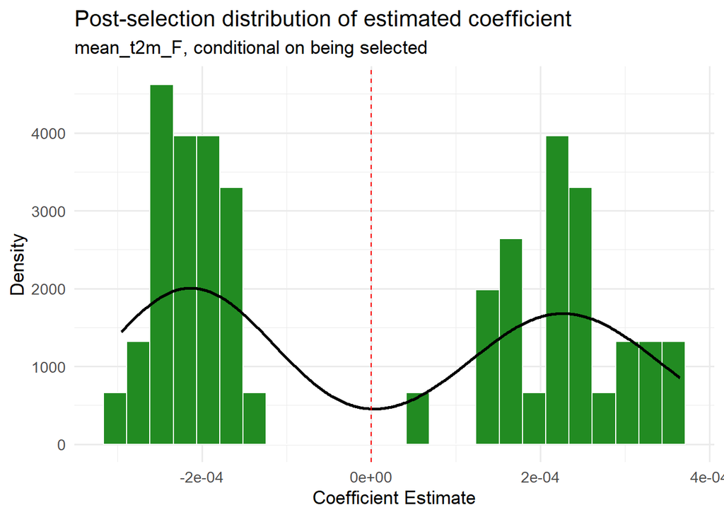

```r
beta_selected <- sim_results$beta_hat[sim_results$selected]
beta_df <- data.frame(beta_selected)

ggplot(beta_df, aes(x = beta_selected)) +
  geom_histogram(aes(y = ..density..),
                 bins = 25,
                 color = "white",
                 fill  = "forestgreen") +
  # add a smooth density curve
  geom_density(linewidth = 1) +
  # true coefficient = 0
  geom_vline(xintercept = 0, linetype = "dashed", color = "red") +
  labs(
    title    = "Post-selection distribution of estimated coefficient",
    subtitle = "mean_t2m_F, conditional on being selected",
    x        = "Coefficient Estimate",
    y        = "Density"
  ) +
  theme_minimal(base_size = 13)
```